# 2019 Master’s Prediction

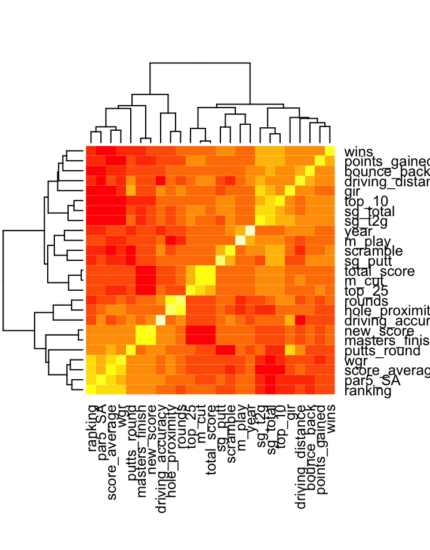

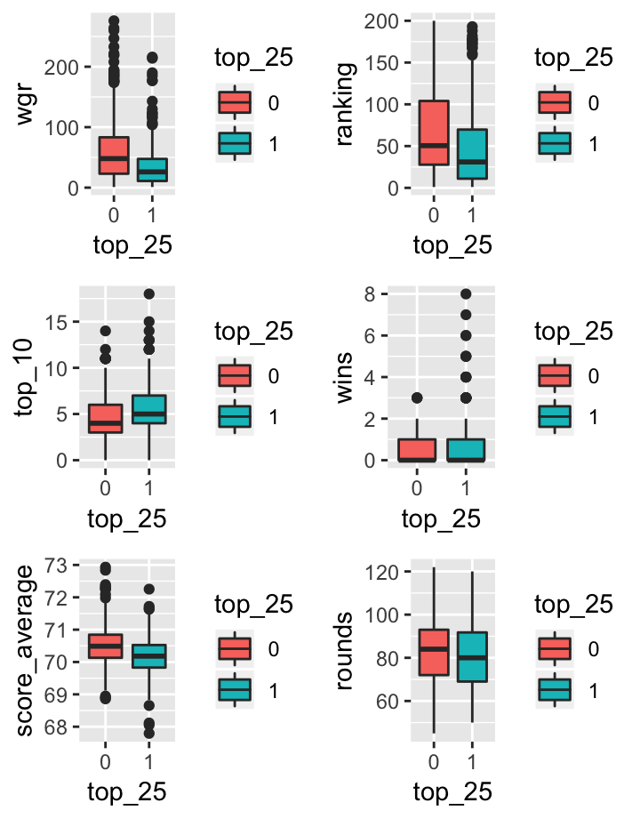

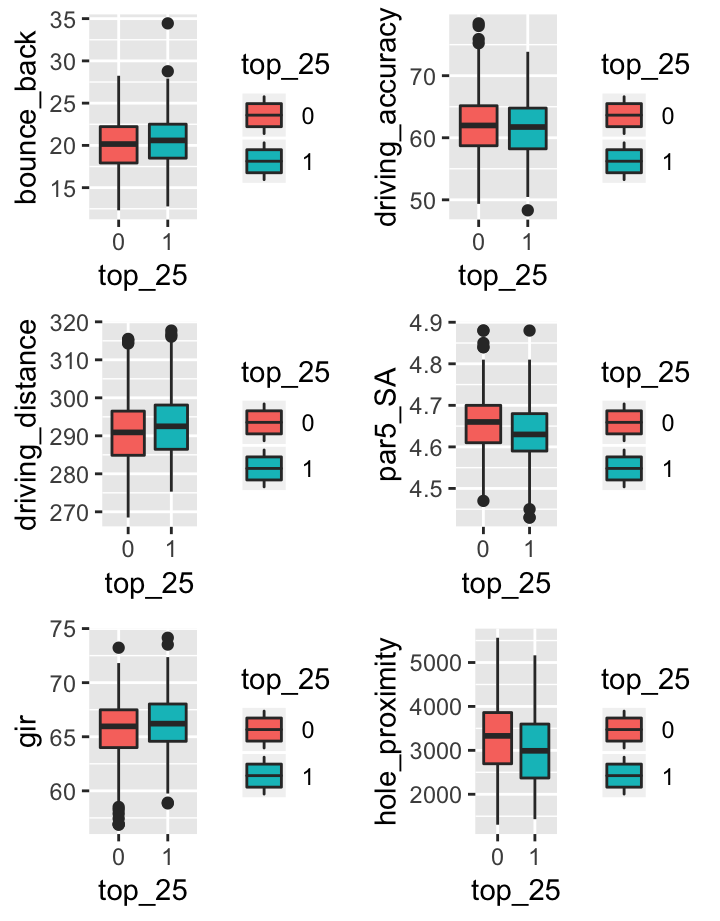

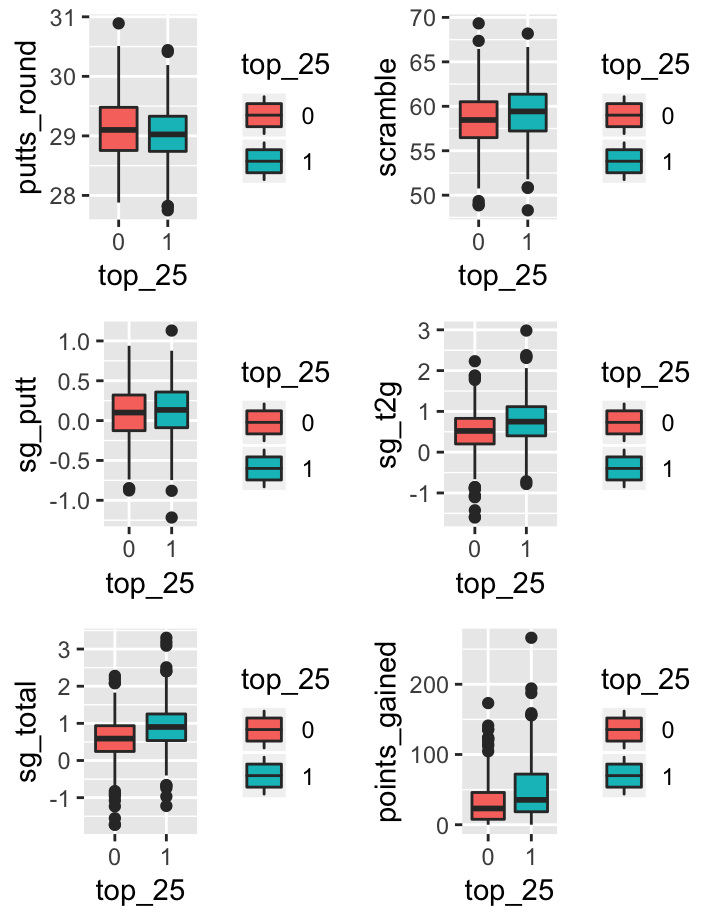

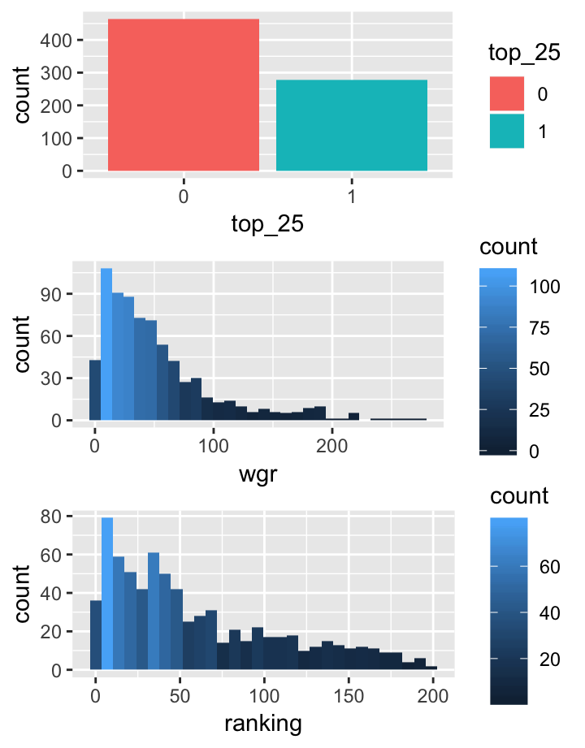

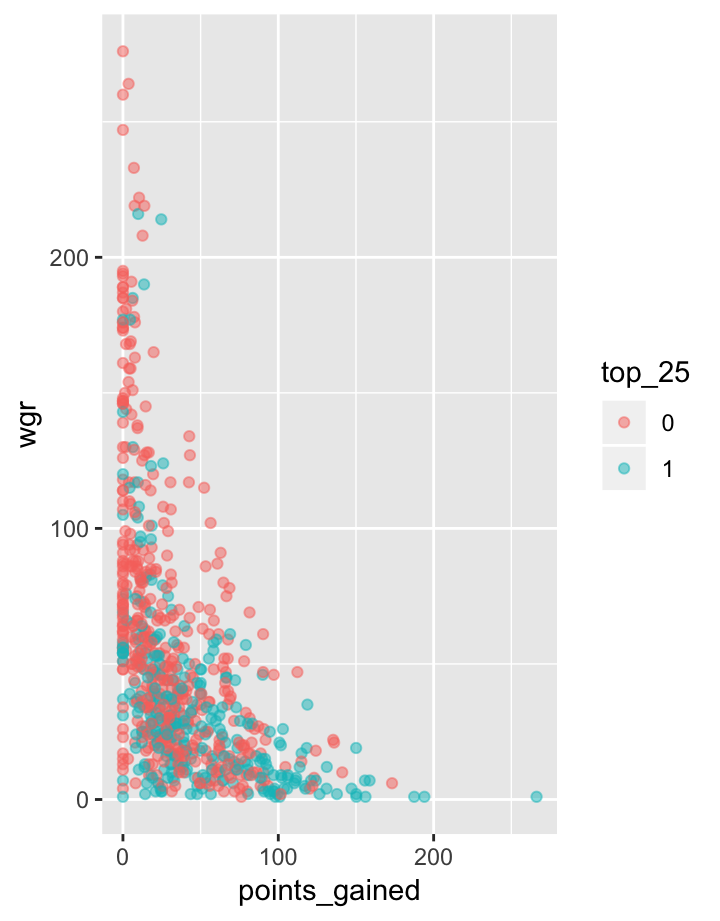

[figure not shown]

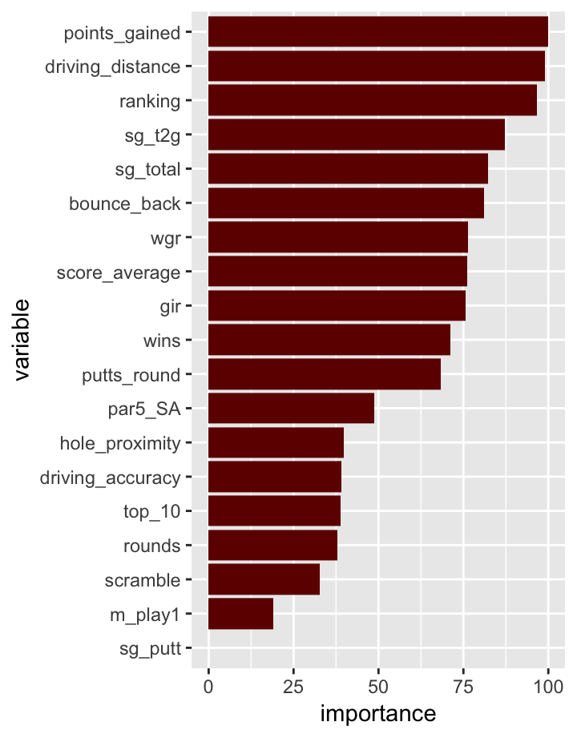

# Overview

**2019 MASTER’S TOURNAMENT PREDICTIONS**

The Github repository for all code and files can be found here: https://github.com/jdubbert/Predicting-2019-Masters

**OBJECTIVE**

The purpose of this project was to identify the best model to predict the 2019 Masters Tournament. I used data from 2005 to 2017, which had a total of 742 observations, for the training and testing datasets. With each model, parameter optimization was performed and cross-validation was used to evaluate model performance. I then used data from 2018 to predict the Masters results for 2019.

In this analysis I went through multiple classification models to predict whether a player would place in the `top_25` of the Master’s Tournament and multiple regression models to predict the `total_score` and finish position for each player. For each model, the optimal set of parameters are selected through brute force: all possible combinations of parameters are looped through, and for each set of parameters the model’s performance is evaluated using cross validation. This is done to avoid overfitting: that is, choosing a model that fits the estimating data very well but does not generalize well to new data.

I divided the PGA data into a “training” set and a “testing” set. The training set is used to estimate the parameters of the model, and then the testing set is used to evaluate the predictions of the model. The classification models are evaluated using accuracy and area under the curve (AUC), and the regression models are evaluated using mean-squared prediction error, which in this context is defined as the difference between our predicted `total_score` and the observed `total_score`, squared and then averaged.

**DATA**

The data is from https://www.pgatour.com/stats.html and consists of yearly PGA Tour player summary statistics from 2005-2018.

Dependent Variables:

- Top 25
- Total Score (Masters)

Independent Variables:

- Played in Masters last year
- Top 10 Finishes
- Strokes Gained Total
- Strokes Gained Putting
- Strokes Gained Tee to Green
- Scoring Average
- Rounds played
- Driving Distance
- Driving Accuracy
- Greens in Regulation (GIR) %
- Ranking (ranking week leading up to masters)
- Wins
- Putts per Round
- Scrambling
- Par 5 scoring average
- Times played in Masters
- Bounce Back Percentage
- Proximity to Hole
- World Golf Ranking (WGR)

**MODELS**

For predicting the `top_25`, the classification models used were:

For predicting the `total_score`, the regression models used were:

**RESULTS**

For the regression problem predicting the final total score, the best model in terms of MSE was the ridge regression with an MSE of 112.

# Data

### Raw Data: 2005-2017

| player_name | year | wgr | masters_finish | total_score | ranking | top_10 | wins | score_average | rounds | bounce_back | driving_accuracy | driving_distance | par5_SA | gir | hole_proximity | putts_round | scramble | sg_putt | sg_t2g | sg_total | points_gained | m_cut | top_25 | new_score | m_play |
| --- | --- | --- | --- | --- | --- | --- | --- | --- | --- | --- | --- | --- | --- | --- | --- | --- | --- | --- | --- | --- | --- | --- | --- | --- | --- |
| Aaron Baddeley | 2006 | 26 | 52 | 307 | 98 | 2 | 1 | 71.197 | 78 | 19.3 | 60.73 | 288.3 | 4.64 | 58.26 | 3928.25 | 27.96 | 59.37 | 0.595 | -0.517 | 0.001 | 90.66 | 1 | 0 | 307 | 0 |
| Aaron Baddeley | 2007 | 18 | 99 | 148 | 44 | 7 | 1 | 70.088 | 83 | 18.07 | 60 | 291.9 | 4.56 | 60.35 | 3627.833 | 28.26 | 60.6 | 0.629 | 0.435 | 1.064 | 27.925 | 0 | 0 | 308 | 1 |
| Aaron Baddeley | 2008 | 52 | 17 | 284 | 34 | 3 | 0 | 70.196 | 76 | 20.2 | 59.45 | 290.3 | 4.61 | 62.02 | 3466.333 | 28.38 | 58.52 | 0.762 | 0.123 | 0.885 | 15.851 | 1 | 1 | 284 | 1 |
| Aaron Baddeley | 2010 | 69 | 47 | 293 | 31 | 2 | 0 | 70.995 | 94 | 27.72 | 56.65 | 298.9 | 4.69 | 64.6 | 4551 | 28.57 | 57.1 | 0.509 | -0.294 | 0.208 | 81.498 | 1 | 0 | 293 | 1 |
| Aaron Baddeley | 2011 | 39 | 40 | 293 | 24 | 5 | 1 | 70.23 | 77 | 26.15 | 55.67 | 296.2 | 4.59 | 65.48 | 3095.917 | 28.39 | 59.44 | 0.324 | 0.824 | 1.148 | 35.244 | 1 | 0 | 293 | 1 |
| Adam Hadwin | 2016 | 46 | 36 | 294 | 17 | 2 | 0 | 70.719 | 93 | 25.4 | 63.62 | 290.1 | 4.66 | 66.07 | 4395.667 | 28.55 | 58.27 | 0.529 | -0.003 | 0.526 | 97.086 | 1 | 0 | 294 | 0 |
| Adam Hadwin | 2017 | 43 | 24 | 287 | 40 | 5 | 1 | 70.583 | 98 | 18.07 | 62.85 | 290.7 | 4.66 | 64.89 | 4101.167 | 28.43 | 63.47 | 0.47 | 0.17 | 0.64 | 50.063 | 1 | 1 | 287 | 1 |
| Adam Scott | 2005 | 11 | 27 | 292 | 81 | 6 | 0 | 70.198 | 72 | 23.35 | 57.4 | 300.1 | 4.6 | 67.24 | 2314.167 | 29.43 | 55.36 | 0.016 | 1.03 | 1.047 | 57.16 | 1 | 0 | 292 | 0 |
| Adam Scott | 2006 | 3 | 27 | 300 | 3 | 10 | 1 | 68.946 | 70 | 19.35 | 62 | 301.1 | 4.61 | 69.12 | 2473.25 | 29.28 | 57.94 | -0.13 | 2.23 | 2.08 | 79.98 | 1 | 0 | 300 | 1 |
| Adam Scott | 2007 | 6 | 25 | 292 | 11 | 6 | 1 | 70.008 | 69 | 23.61 | 59.17 | 300.9 | 4.6 | 65.44 | 2730.75 | 29.34 | 52.01 | 0.129 | 1.105 | 1.234 | 71 | 1 | 1 | 292 | 1 |

[output cut: 732 more lines]

### Summary Stats

```
=====================================================================
Statistic         N  St. Dev.   Mean     Median      Min       Max
---------------------------------------------------------------------
year             742  3.722   2,010.877   2,011     2,005     2,017
wgr              742  48.358   52.000      38         1        276
masters_finish   742  37.332   48.957      37         1        99
total_score      742  65.382   243.993     286       76        311
ranking          742  50.795   60.065     43.5        1        200
top_10           742  2.731     4.790       5         0        18
wins             742  0.920     0.620       0         0         8
score_average    742  0.629    70.374    70.362    67.794    72.933
rounds           742  14.791   81.307      83        45        122
bounce_back      742  3.088    20.323    20.260    12.320    34.440
driving_accuracy 742  4.930    62.047    61.930    48.310    78.430
driving_distance 742  8.698    291.623   291.600   268.500   317.700
par5_SA          742  0.067     4.648     4.650     4.430     4.880
gir              742  2.623    65.884    66.070    56.870    74.150
hole_proximity   742 810.434  3,185.853 3,205.792 1,306.750 5,563.583
putts_round      742  0.497    29.084    29.070    27.750    30.890
scramble         742  3.252    58.724    58.865    48.300    69.330
sg_putt          742  0.333     0.108     0.118    -1.216     1.130
sg_t2g           742  0.568     0.596     0.594    -1.602     2.982
sg_total         742  0.622     0.700     0.698    -1.728     3.304
points_gained    742  35.612   37.507    28.020     0.000    266.240
m_cut            742  0.471     0.670       1         0         1
top_25           742  0.484     0.375       0         0         1
new_score        742  12.412   296.823     294       236       388
m_play           742  0.452     0.714       1         0         1
---------------------------------------------------------------------
```

# Data Exploration

### Correlations

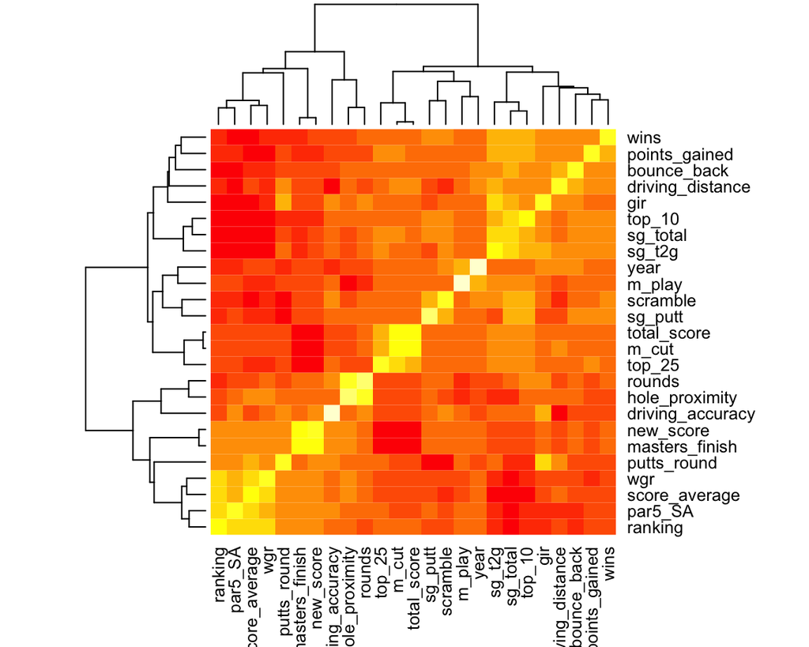

### Plot Against Top 25

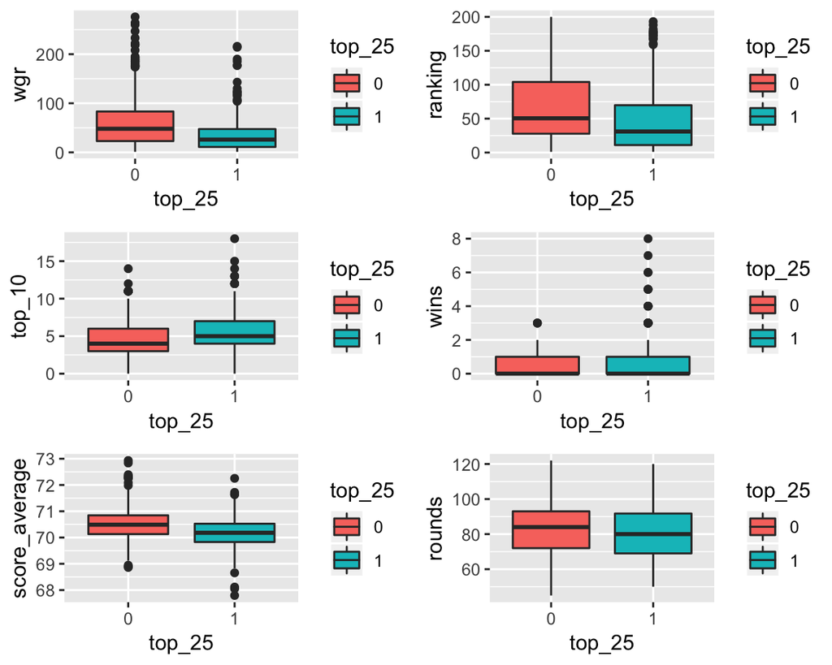

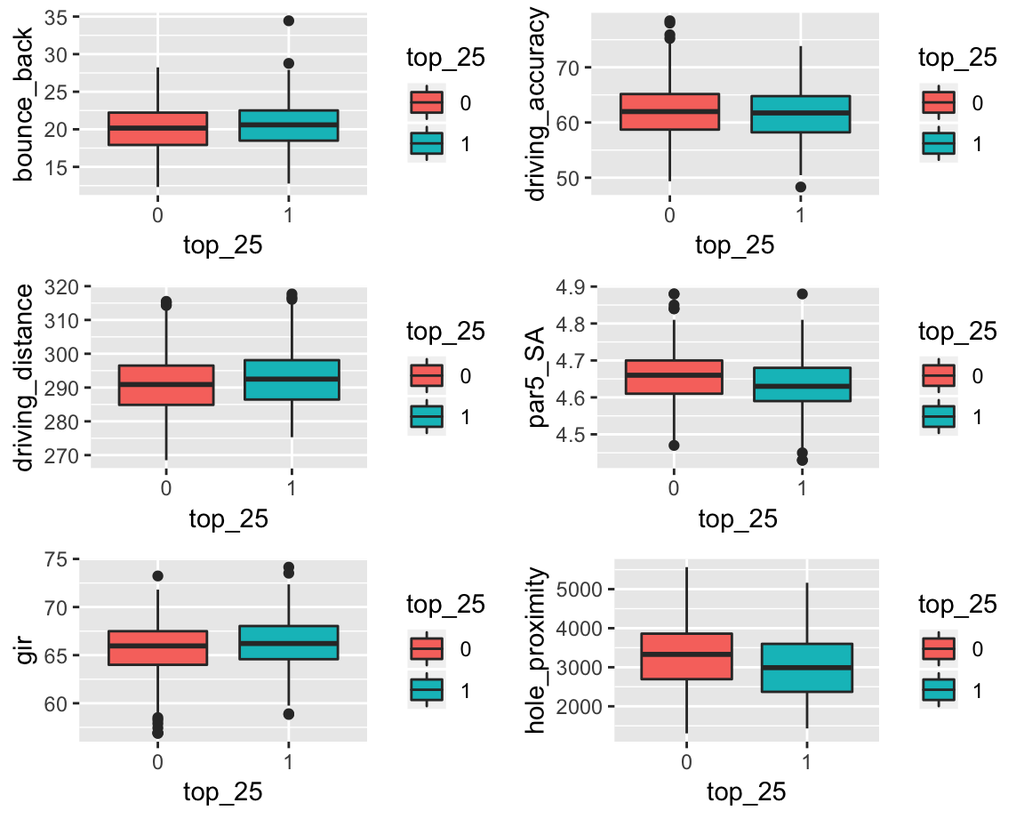

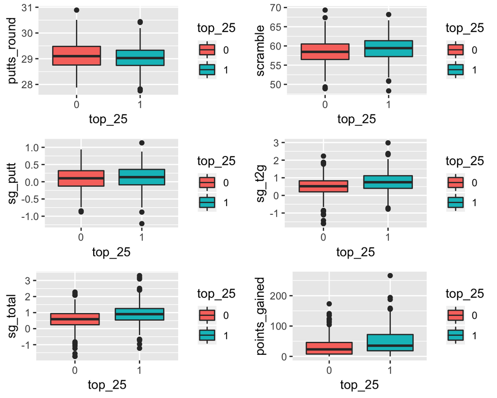

### Distributions

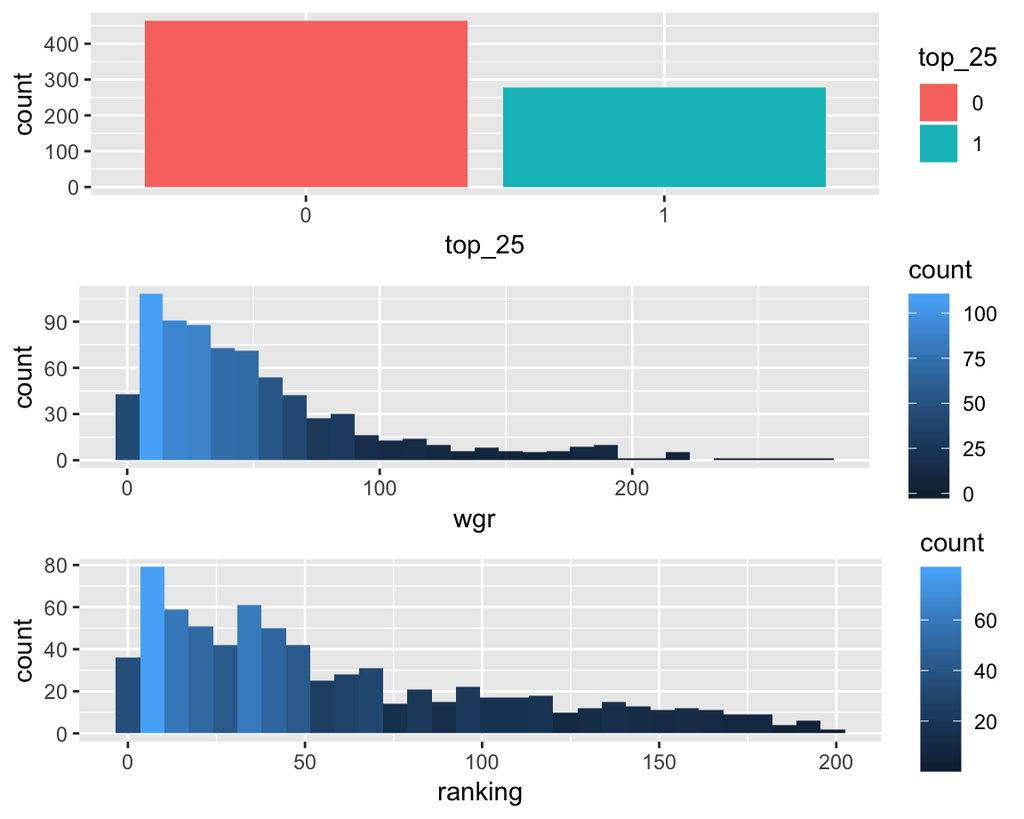

### Bivariate Relationships

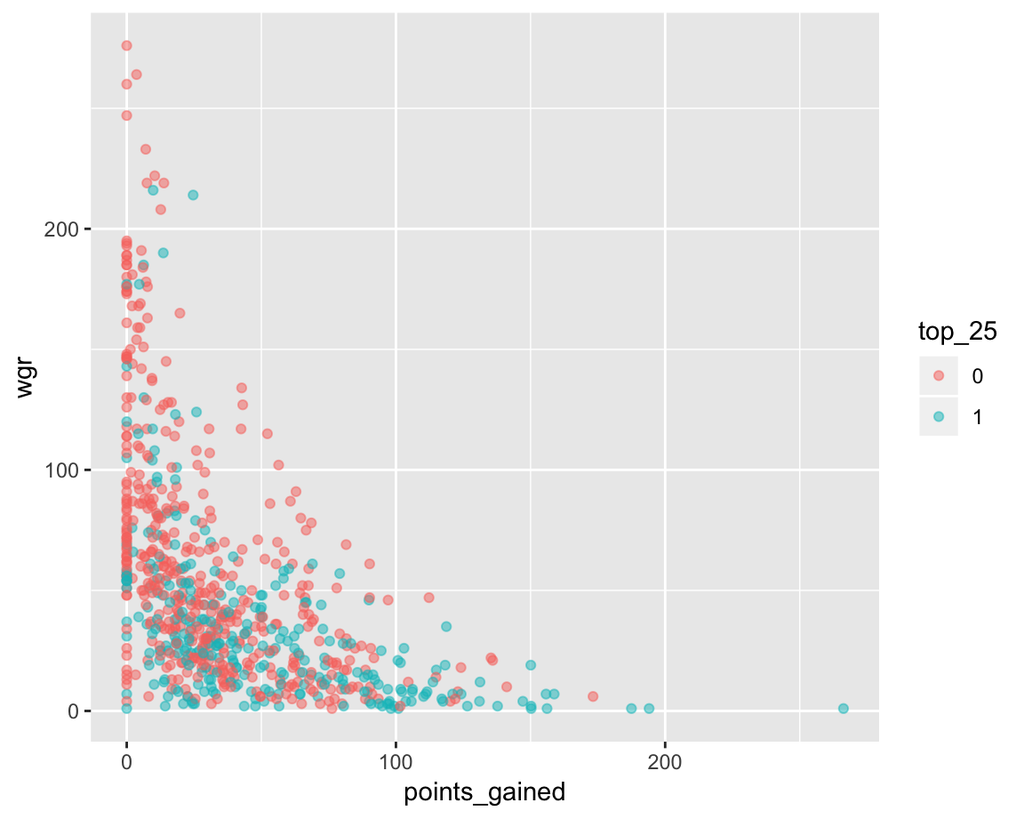

# Classification Models

### Comparison of AUC across models

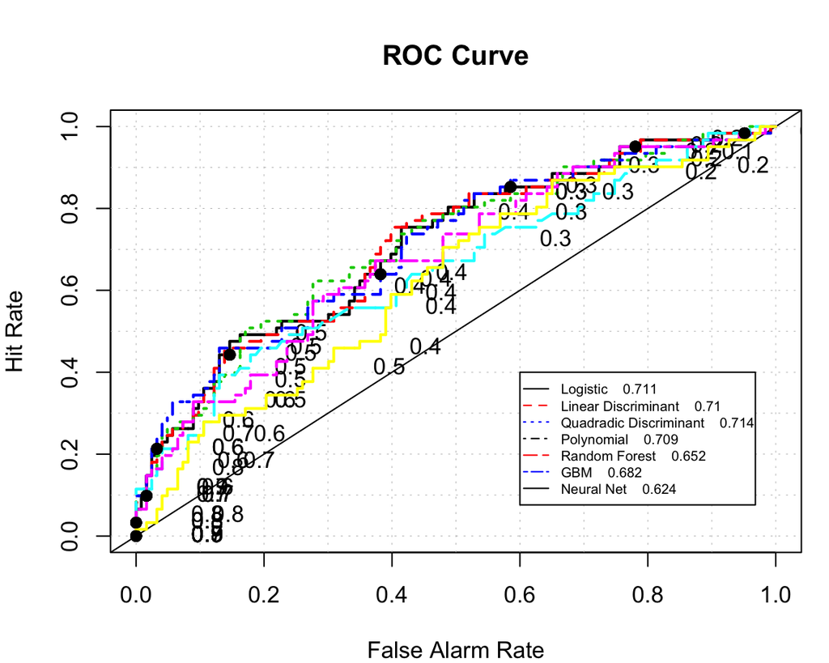

### AUC Comparison

[output not shown]

# Regression Models

### Compare Performance of All Models

|  | model | MSE |
| --- | --- | --- |
| 1 | ridge | 112.351486207333 |
| 2 | lm | 113.217269911265 |
| 3 | random_forest | 114.478166747947 |
| 4 | gradient_boosting | 114.550483599012 |
| 5 | neural_net | 120.430209561095 |
| 6 | bagged | 124.382320138593 |

### Important Predictors for Random Forest

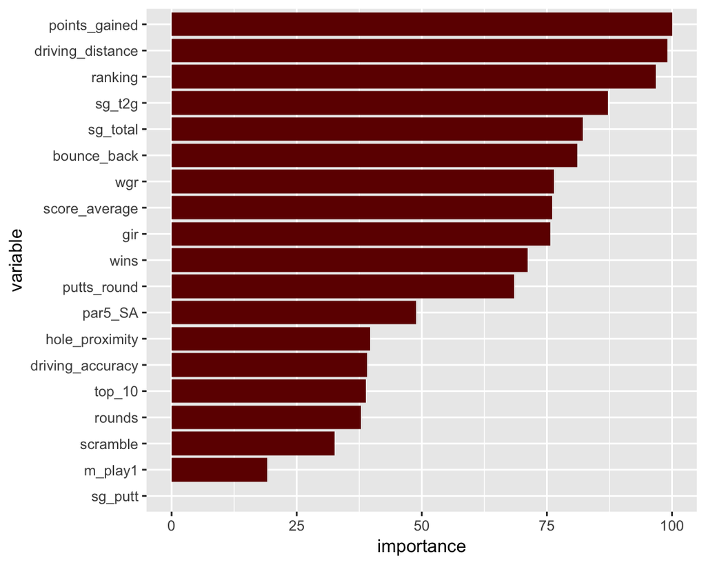